Skip to contents

# Listings & Figures

Source: [`vignettes/listings-and-figures.Rmd`](https://github.com/vthanik/arframe/blob/HEAD/vignettes/listings-and-figures.Rmd)

## Listings

`fr_listing()` creates a spec optimised for record-level patient listings. It uses the same pipeline verbs as `fr_table()` but with different defaults:

| Feature | `fr_table()` | `fr_listing()` |
| --- | --- | --- |
| Font size | 9pt | 8pt |
| Alignment | Auto-detect | Left |
| Text wrapping | Off | On |
| Column splitting | Off | On |
| H-lines | None | `"header"` |

### AE Listing (16.2.7.1)

```r
ae_list <- adae[1:40, c("USUBJID", "AEBODSYS", "AEDECOD",
                         "AESEV", "AESER", "AEREL", "AEACN")]
ae_listing_spec <- ae_list |>
  fr_listing() |>
  fr_titles(
    "Listing 16.2.7.1",
    list("Adverse Events", bold = TRUE),
    "Safety Population"
  ) |>
  fr_cols(
    USUBJID  = fr_col("Subject ID", width = 1.3),
    AEBODSYS = fr_col("System Organ Class", width = 1.8),
    AEDECOD  = fr_col("Preferred Term", width = 1.5),
    AESEV    = fr_col("Severity", width = 0.8),
    AESER    = fr_col("Serious", width = 0.7),
    AEREL    = fr_col("Related", width = 0.8),
    AEACN    = fr_col("Action", width = 1.2)
  ) |>
  fr_rows(sort_by = c("USUBJID", "AEBODSYS", "AEDECOD"),
          suppress = "USUBJID") |>
  fr_footnotes(
    "Related = Probable or Possible.",
    "Action = Action taken with study drug."
  )
fr_validate(ae_listing_spec)
```

```r
ae_listing_spec |> fr_render("output/Listing_16_2_7_1.rtf")
```

Listing 16.2.7.1

Adverse Events

Safety Population

| Subject ID | System Organ Class | Preferred Term | Severity | Serious | Related | Action |
| --- | --- | --- | --- | --- | --- | --- |
| TFR-001-0001 | Infections and infestations | Nasopharyngitis | MILD | N | NONE | DOSE NOT CHANGED |
|  | Respiratory, thoracic and mediastinal disorders | Rhinorrhoea | MILD | N | NONE | DOSE NOT CHANGED |
| TFR-001-0003 | Gastrointestinal disorders | Flatulence | MODERATE | N | NONE | DOSE NOT CHANGED |
|  | Infections and infestations | Nasopharyngitis | MILD | N | NONE | DOSE NOT CHANGED |
|  | Renal and urinary disorders | Incontinence | MILD | N | NONE | DOSE NOT CHANGED |
| TFR-001-0015 | Gastrointestinal disorders | Nausea | MILD | N | NONE | DOSE NOT CHANGED |
| TFR-001-0016 | Cardiac disorders | Palpitations | MILD | N | NONE | DOSE NOT CHANGED |
|  | Gastrointestinal disorders | Abdominal pain upper | MILD | N | NONE | DOSE NOT CHANGED |
|  | General disorders and administration site conditions | Fatigue | MILD | N | NONE | DOSE NOT CHANGED |
|  | Musculoskeletal and connective tissue disorders | Back pain | MODERATE | N | NONE | DRUG INTERRUPTED |
|  | Nervous system disorders | Headache | MILD | N | NONE | DOSE NOT CHANGED |
| TFR-001-0021 | Metabolism and nutrition disorders | Weight decreased | MILD | N | NONE | DOSE NOT CHANGED |
|  | Musculoskeletal and connective tissue disorders | Arthralgia | MILD | N | REMOTE | DOSE NOT CHANGED |
|  | Respiratory, thoracic and mediastinal disorders | Epistaxis | MILD | N | REMOTE | DOSE NOT CHANGED |
|  | Respiratory, thoracic and mediastinal disorders | Oropharyngeal pain | MILD | N | POSSIBLE | DOSE NOT CHANGED |
|  | Vascular disorders | Hypotension | MODERATE | N | PROBABLE | DOSE NOT CHANGED |
| TFR-001-0024 | Gastrointestinal disorders | Diarrhoea | MILD | N | NONE | DOSE NOT CHANGED |
|  | General disorders and administration site conditions | Fatigue | MILD | N | NONE | DOSE NOT CHANGED |
|  | Metabolism and nutrition disorders | Dehydration | MILD | N | PROBABLE | DOSE NOT CHANGED |
|  | Musculoskeletal and connective tissue disorders | Back pain | MODERATE | N | NONE | DRUG INTERRUPTED |
|  | Psychiatric disorders | Hallucination | SEVERE | N | POSSIBLE | DOSE REDUCED |
| TFR-001-0025 | General disorders and administration site conditions | Fatigue | SEVERE | N | REMOTE | DRUG INTERRUPTED |
|  | Vascular disorders | Flushing | MILD | N | PROBABLE | NOT APPLICABLE |
| TFR-001-0040 | Cardiac disorders | Palpitations | MILD | N | NONE | DOSE NOT CHANGED |
|  | Eye disorders | Conjunctivitis | MODERATE | N | NONE | DOSE REDUCED |
|  | Gastrointestinal disorders | Diarrhoea | MILD | N | POSSIBLE | DOSE NOT CHANGED |
|  | General disorders and administration site conditions | Fatigue | MILD | N | NONE | NOT APPLICABLE |
|  | Musculoskeletal and connective tissue disorders | Pain in extremity | MILD | N | NONE | DOSE NOT CHANGED |
|  | Nervous system disorders | Dizziness | MILD | N | NONE | DOSE NOT CHANGED |
|  | Renal and urinary disorders | Incontinence | MILD | N | NONE | NOT APPLICABLE |
| TFR-001-0042 | Eye disorders | Conjunctivitis | MODERATE | N | PROBABLE | DOSE NOT CHANGED |
|  | Infections and infestations | Urinary tract infection | SEVERE | N | PROBABLE | DOSE REDUCED |
|  | Metabolism and nutrition disorders | Decreased appetite | MODERATE | N | POSSIBLE | DOSE NOT CHANGED |
|  | Metabolism and nutrition disorders | Weight decreased | MODERATE | N | NONE | DRUG INTERRUPTED |
|  | Musculoskeletal and connective tissue disorders | Back pain | MILD | N | PROBABLE | DOSE NOT CHANGED |
|  | Musculoskeletal and connective tissue disorders | Myalgia | MODERATE | N | NONE | DOSE NOT CHANGED |
|  | Nervous system disorders | Insomnia | MILD | N | NONE | DOSE NOT CHANGED |
|  | Psychiatric disorders | Anxiety | SEVERE | Y | POSSIBLE | DRUG WITHDRAWN |
|  | Reproductive system and breast disorders | Erectile dysfunction | MILD | N | NONE | DOSE NOT CHANGED |
|  | Skin and subcutaneous tissue disorders | Rash | MODERATE | N | PROBABLE | DOSE NOT CHANGED |

Related = Probable or Possible.

Action = Action taken with study drug.

/tmp/RtmpgVlH1h/callr-scr-2eadf56f50edc 25MAR2026 21:13:47

### Key listing features

**`sort_by`** orders rows by the named columns:

```r
spec <- adae[1:10, c("USUBJID", "AEDECOD", "AESEV")] |>
  fr_listing() |>
  fr_rows(sort_by = c("USUBJID", "AEDECOD"))
```

**`suppress`** suppresses repeated values (like SAS `NOREPEAT`):

```r
spec <- adae[1:10, c("ARM", "USUBJID", "AEDECOD")] |>
  fr_listing() |>
  fr_rows(sort_by = c("ARM", "USUBJID"),
          suppress = c("ARM", "USUBJID"))
```

**`wrap = TRUE`** enables automatic text wrapping (on by default in listings):

```r
spec <- adae[1:5, c("USUBJID", "AEBODSYS")] |>
  fr_listing() |>
  fr_rows(wrap = TRUE)
```

## Figures

`fr_figure()` wraps a ggplot2 or base R plot into the same pipeline, giving it titles, footnotes, page headers, and footers:

```r
# fr_figure() wraps a ggplot2 or base R plot
# pagehead/pagefoot are inherited from fr_theme() --- no need to repeat
my_plot |>
  fr_figure(width = 8, height = 5) |>
  fr_titles(
    "Figure 14.2.1",
    "Kaplan-Meier Plot of Time to Study Withdrawal"
  )
```

### With ggplot2

```r
if (requireNamespace("ggplot2", quietly = TRUE)) {
  library(ggplot2)
  km_plot <- ggplot(adtte, aes(x = AVAL, colour = ARM)) +
    stat_ecdf(geom = "step") +
    labs(x = "Days", y = "Proportion Event-Free") +
    theme_minimal()

  fig_spec <- km_plot |>
    fr_figure(width = 8, height = 5) |>
    fr_titles(
      "Figure 14.2.1",
      "Kaplan-Meier Plot of Time to Study Withdrawal",
      "Intent-to-Treat Population"
    ) |>
    fr_footnotes("Tick marks indicate censored observations.")
}
```

```r
fig_spec |> fr_render("output/Figure_14_2_1.pdf")
```

Figure 14.2.1

Intent-to-Treat Population

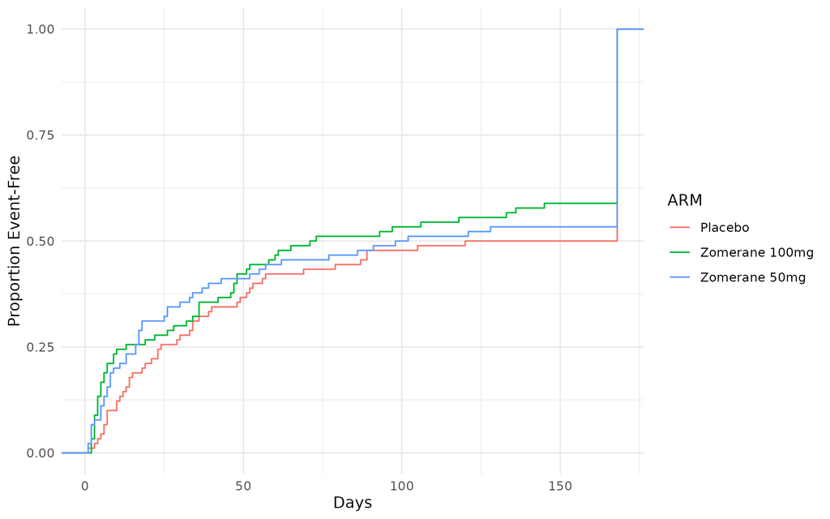

/tmp/RtmpgVlH1h/callr-scr-2eadf56f50edc 25MAR2026 21:13:48

### Multi-page figures

Pass a list of plots to create a multi-page figure. Add a `meta` data frame to inject per-page tokens into titles and footnotes:

```r
# Three KM plots --- one per subgroup
km_plots <- list(p_adults, p_pediatrics, p_geriatrics)
page_meta <- data.frame(
  subgroup = c("Adults", "Pediatrics", "Geriatrics"),
  n        = c(80, 55, 30)
)

km_plots |>
  fr_figure(meta = page_meta) |>
  fr_titles(
    "Figure 14.1.1 Kaplan-Meier Curve",
    "Subgroup: {subgroup} (N = {n})"
  ) |>
  fr_footnotes("Source: ADTTE") |>
  fr_render("km_by_subgroup.rtf")
```

Each `meta` column name becomes a `{token}` resolved dynamically per page. The second title line renders as “Subgroup: Adults (N = 80)” on page 1, “Subgroup: Pediatrics (N = 55)” on page 2, and so on.

### Figure parameters

| Parameter | Default | Description |
| --- | --- | --- |
| `plot` | (required) | ggplot2 object, recorded base R plot, or a list of either |
| `width` | `NULL` | Plot width in inches (auto-sized from page if `NULL`) |
| `height` | `NULL` | Plot height in inches (70% of printable height if `NULL`) |
| `meta` | `NULL` | Data frame with one row per plot; columns become `{token}` names in titles/footnotes |